# Kelly Criterion

Xin Wang & Levi C. Nicklas

```r
library(CVXR)
library(tidyverse)
library(reshape2)
```

# Introduction

The Kelly criterion, also known as Kelly gambling, is a formula that aims to provide the optimal size bet to make. What is particularly nice about this method, is that it is *intertemporal*, meaning it is independent of time. This means you only have to calculate it once, and then stick to the plan given that the circumstances of the game have not changed. This problem can be viewed as a convex optimization problem where the goal is to maximize the rate at which your wealth grows.

# About Kelly Gambling

# Convex Optimization of Kelly Gambling

First we demonstrate how the Kelly gambling problem can be viewed as a convex optimization problem.

In the case for Kelly gambling, our function we aim to maximize is the average growth rate of our wealth.

We reproduce the result from the `CVX` paper, Example 4.6, by adapting the MatLab code to `R`.

## Find Optimal Value

```r
# Initial Bankroll
w0 = 100

# Input data from CVXR Example.
P <- c(3.5000, 1.1100, 1.1100, 1.0400, 1.0100,
     0.5000, 0.9700, 0.9800, 1.0500, 1.0100,
     0.5000, 0.9900, 0.9900, 0.9900, 1.0100,
     0.5000, 1.0500, 1.0600, 0.9900, 1.0100,
     0.5000, 1.1600, 0.9900, 1.0700, 1.0100,
     0.5000, 0.9900, 0.9900, 1.0600, 1.0100,
     0.5000, 0.9200, 1.0800, 0.9900, 1.0100,
     0.5000, 1.1300, 1.1000, 0.9900, 1.0100,
     0.5000, 0.9300, 0.9500, 1.0400, 1.0100,
     3.5000, 0.9900, 0.9700, 0.9800, 1.0100)



# Reformat to Matrix
P <- matrix(P, ncol = 5, byrow = TRUE)

#P <- rnorm(100, mean = 1, sd = 0.2)
#P <- matrix(P, ncol = 5, byrow = TRUE)

# Save Matrix Dimensions
P_dim <- dim(P)

# Probabilities
ps <- rep(1, P_dim[1]) / P_dim[1]


# Proportion of Wealth Bet
b <- CVXR::Variable(P_dim[2])
```

```r
constr <- list(b >= 0, sum(b) == 1)

prob <- CVXR::Problem(
  CVXR::Maximize(sum(t(ps) %*% log(P %*% b))),
  constr)

result <- solve(prob)
result$value
```

```
[1] 0.02307832
```

```r
result$getValue(b)
```

```
             [,1]
[1,] 5.797428e-02
[2,] 3.999829e-01
[3,] 2.922723e-01
[4,] 2.497705e-01
[5,] 2.689230e-09
```

## Simulations

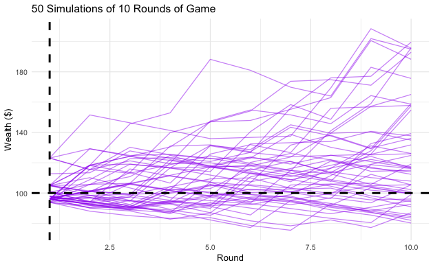

```r
# 1 Simulation
# bets <- result$getValue(b)
# idx <- sample.int(10, size = 10, prob =  ps, replace = TRUE)
# winnings <- P[idx,] %*% bets
# wealth <- w0 * cumprod(winnings)

# Multiple Simulations
n_sim <- 50
simulations <- matrix(rep(0,10*n_sim), nrow = 10)

for(i in 1:n_sim){
  bets <- result$getValue(b)
  idx <- sample.int(10, size = 10, prob =  ps, replace = TRUE)
  winnings <- P[idx,] %*% bets
  wealth <- w0 * cumprod(winnings)

  simulations[,i] <- wealth
}



simulations %>%
  melt() %>%
  group_by(Var2) %>%
  ggplot(aes(Var1, value, group = Var2)) +
  geom_line(color = "purple" , alpha = 0.5) +
  geom_hline(yintercept = 100, color = "black", size = 1.15, linetype = "dashed") +
  geom_vline(xintercept = 1,  color = "black", size = 1.15, linetype = "dashed")+
  labs(title = "50 Simulations of 10 Rounds of Game",
       x = "Round",
       y = "Wealth ($)") +
  theme_minimal()
```

```r
NA
NA
NA
```

# References

$^{[2]}$ : http://www.diva-portal.org/smash/get/diva2:812697/FULLTEXT01.pdf